# Summary stats

## Cell-wise stats

```python
cell_table = pd.read_csv(cell_table_csv).query("uid in @metadata.index")
cell_table.to_csv(f"{output_dir}/cell_table.csv", index=False)
cell_table
```

|  | ID_HK | well | uid | ngs_id | mouse | gc | node | cell_type | imm_duration | aa_substitutions_IMGT | ... | fasta_header_HC | fasta_header_LC | fasta_seq_HC | fasta_seq_LC | partis_sequence_HC | partis_sequence_LC | seq_aa_HC | seq_aa_LC | seq_nt_HC | seq_nt_LC |
| --- | --- | --- | --- | --- | --- | --- | --- | --- | --- | --- | --- | --- | --- | --- | --- | --- | --- | --- | --- | --- | --- |
| 0 | 230512P15A02HK | A02 | D15_M6_GC11 | PR-2-01 | 6 | 11 | RP | GC | d15 | P9(H)L S11(H)G I42(H)L S64(H)C R106(H)W R67(L)... | ... | PR-2-01.230512.P15.A02.H.R.1-51 | PR-2-01.230512.P14.A02.K.R.1-442 | GAGGTGCAGCTTCAGGAGTCAGGACTTGGCCTCGTGAAACCTTCTC... | GTGTTGATGGAGACATTGTGATGACTCAGTCTCAAAAATTCATGTC... | GAGGTGCAGCTTCAGGAGTCAGGACTTGGCCTCGTGAAACCTTCTC... | GACATTGTGATGACTCAGTCTCAAAAATTCATGTCCACATCAGTAG... | EVQLQESGLGLVKPSQTLSLTCSVTGDSITSGYWNWLRKFPGNKLE... | DIVMTQSQKFMSTSVGDRVSVTCKASQNVGTNVAWYQQKPGQSPKA... | gaggtgcagcttcaggagtcaggacttggcctcgtgaaaccttctc... | gacattgtgatgactcagtctcaaaaattcatgtccacatcagtag... |
| 1 | 230512P15A03HK | A03 | D15_M6_GC11 | PR-2-01 | 6 | 11 | RP | GC | d15 | M53(H)V S57(H)N Y67(H)S K51(L)R A52(L)S N93(L)... | ... | PR-2-01.230512.P15.A03.H.R.1-211 | PR-2-01.230512.P14.A03.K.R.1-332 | GAGGTGCAGCTTCAGGAGTCAGGACCTAGCCTCGTGAAACCTTCTC... | GTGTTGATGGAGACATTGTGATGACTCAGTCTCAAAAATTCATGTC... | GAGGTGCAGCTTCAGGAGTCAGGACCTAGCCTCGTGAAACCTTCTC... | GACATTGTGATGACTCAGTCTCAAAAATTCATGTCCACATCAGTAG... | EVQLQESGPSLVKPSQTLSLTCSVTGDSITSGYWNWIRKFPGNKLE... | DIVMTQSQKFMSTSVGDRVSVTCKASQNVGTNVAWYQQKPGQSPRS... | gaggtgcagcttcaggagtcaggacctagcctcgtgaaaccttctc... | gacattgtgatgactcagtctcaaaaattcatgtccacatcagtag... |
| 2 | 230512P15A04HK | A04 | D15_M6_GC11 | PR-2-01 | 6 | 11 | RP | GC | d15 | T96(H)N Y103(H)* A105(H)G | ... | PR-2-01.230512.P15.A04.H.R.1-67 | PR-2-01.230512.P14.A04.K.R.1-364 | GAGGTGCAGCTTCAGGAGTCAGGACCTAGCCTCGTGAAACCTTCTC... | GTGTTGATGGAGACATTGTGATGACTCAGTCTCAAAAATTCATGTC... | GAGGTGCAGCTTCAGGAGTCAGGACCTAGCCTCGTGAAACCTTCTC... | GACATTGTGATGACTCAGTCTCAAAAATTCATGTCCACATCAGTAG... | EVQLQESGPSLVKPSQTLSLTCSVTGDSITSGYWNWIRKFPGNKLE... | DIVMTQSQKFMSTSVGDRVSVTCKASQNVGTNVAWYQQKPGQSPKA... | gaggtgcagcttcaggagtcaggacctagcctcgtgaaaccttctc... | gacattgtgatgactcagtctcaaaaattcatgtccacatcagtag... |
| 3 | 230512P15A05HK | A05 | D15_M6_GC11 | PR-2-01 | 6 | 11 | RP | GC | d15 | S64(H)G K84(H)Q N92(H)K A105(H)G N108(L)K T117... | ... | PR-2-01.230512.P15.A05.H.R.1-54 | PR-2-01.230512.P14.A05.K.R.1-453 | GAGGTGCAGCTTCAGGAGTCAGGACCTAGCCTCGTGAAACCTTCTC... | GTGTTGATGGAGACATTGTGATGACTCAGTCTCAAAAATTCATGTC... | GAGGTGCAGCTTCAGGAGTCAGGACCTAGCCTCGTGAAACCTTCTC... | GACATTGTGATGACTCAGTCTCAAAAATTCATGTCCACATCAGTAG... | EVQLQESGPSLVKPSQTLSLTCSVTGDSITSGYWNWIRKFPGNKLE... | DIVMTQSQKFMSTSVGDRVSVTCKASQNVGTNVAWYQQKPGQSPKA... | gaggtgcagcttcaggagtcaggacctagcctcgtgaaaccttctc... | gacattgtgatgactcagtctcaaaaattcatgtccacatcagtag... |
| 4 | 230512P15A06HK | A06 | D15_M6_GC11 | PR-2-01 | 6 | 11 | RP | GC | d15 | T18(H)P N40(H)S T65(H)N A100(H)V T122(H)M K51(... | ... | PR-2-01.230512.P15.A06.H.R.1-46 | PR-2-01.230512.P14.A06.K.R.1-194 | GAGGTGCAGCTTCAGGAGTCAGGACCTAGCCTCGTGAAACCTTCTC... | GTGTTGATGGAGACATTGTGATGACTCAGTCTCAAAAATTCATGTC... | GAGGTGCAGCTTCAGGAGTCAGGACCTAGCCTCGTGAAACCTTCTC... | GACATTGTGATGACTCAGTCTCAAAAATTCATGTCCACATCAGTAG... | EVQLQESGPSLVKPSQPLSLTCSVTGDSITSGYWSWIRKFPGNKLE... | DIVMTQSQKFMSTSVGDRVSVTCKASQNVGTNVAWYQQKPGQSPRS... | gaggtgcagcttcaggagtcaggacctagcctcgtgaaaccttctc... | gacattgtgatgactcagtctcaaaaattcatgtccacatcagtag... |
| ... | ... | ... | ... | ... | ... | ... | ... | ... | ... | ... | ... | ... | ... | ... | ... | ... | ... | ... | ... | ... | ... |
| 10424 | 211014P07H08HK | H08 | D20_M22_GC88 | PR-1-03 | 22 | 88 | LP | GC | d20 | T26(H)S Y55(H)F L116(L)P | ... | PR-1-03.211014.P07.H08.H.R.1-72 | PR-1-03.211014.P07.H08.K.R.1-22 | GAGGTGCAGCTTCAGGAGTCAGGACCTAGCCTCGTGAAACCTTCTC... | GTGTTGATGGAGACATTGTGATGACTCAGTCTCAAAAATTCATGTC... | GAGGTGCAGCTTCAGGAGTCAGGACCTAGCCTCGTGAAACCTTCTC... | GACATTGTGATGACTCAGTCTCAAAAATTCATGTCCACATCAGTAG... | EVQLQESGPSLVKPSQTLSLTCSVSGDSITSGYWNWIRKFPGNKLE... | DIVMTQSQKFMSTSVGDRVSVTCKASQNVGTNVAWYQQKPGQSPKA... | gaggtgcagcttcaggagtcaggacctagcctcgtgaaaccttctc... | gacattgtgatgactcagtctcaaaaattcatgtccacatcagtag... |
| 10425 | 211014P07H09HK | H09 | D20_M22_GC88 | PR-1-03 | 22 | 88 | LP | GC | d20 | S64(H)N A105(H)G T37(L)A Y68(L)F Q105(L)H | ... | PR-1-03.211014.P07.H09.H.R.1-13 | PR-1-03.211014.P07.H09.K.R.1-164 | GAGGTGCAGCTTCAGGAGTCAGGACCTAGCCTCGTGAAACCTTCTC... | GTGTGGATGGAGACATTGTGATGACTCAGTCTCAAAAATTCATGTC... | GAGGTGCAGCTTCAGGAGTCAGGACCTAGCCTCGTGAAACCTTCTC... | GACATTGTGATGACTCAGTCTCAAAAATTCATGTCCACATCAGTAG... | EVQLQESGPSLVKPSQTLSLTCSVTGDSITSGYWNWIRKFPGNKLE... | DIVMTQSQKFMSTSVGDRVSVTCKASQNVGANVAWYQQKPGQSPKA... | gaggtgcagcttcaggagtcaggacctagcctcgtgaaaccttctc... | gacattgtgatgactcagtctcaaaaattcatgtccacatcagtag... |
| 10426 | 211014P07H10HK | H10 | D20_M22_GC88 | PR-1-03 | 22 | 88 | LP | GC | d20 | S64(H)G T79(H)A N92(H)I A105(H)G T37(L)A N108(... | ... | PR-1-03.211014.P07.H10.H.R.1-11 | PR-1-03.211014.P07.H10.K.R.1-175 | GAGGTGCAGCTTCAGGAGTCAGGACCTAGCCTCGTGAAACCTTCTC... | GTGTTGATGGAGACATTGTGATGACTCAGTCTCAAAAATTCATGTC... | GAGGTGCAGCTTCAGGAGTCAGGACCTAGCCTCGTGAAACCTTCTC... | GACATTGTGATGACTCAGTCTCAAAAATTCATGTCCACATCAGTAG... | EVQLQESGPSLVKPSQTLSLTCSVTGDSITSGYWNWIRKFPGNKLE... | DIVMTQSQKFMSTSVGDRVSVTCKASQNVGANVAWYQQKPGQSPKA... | gaggtgcagcttcaggagtcaggacctagcctcgtgaaaccttctc... | gacattgtgatgactcagtctcaaaaattcatgtccacatcagtag... |
| 10427 | 211014P07H11HK | H11 | D20_M22_GC88 | PR-1-03 | 22 | 88 | LP | GC | d20 | D28(H)A S57(H)N N92(H)I A105(H)G T37(L)A A57(L... | ... | PR-1-03.211014.P07.H11.H.R.1-14 | PR-1-03.211014.P07.H11.K.R.1-188 | GAGGTGCAGCTTCAGGAGTCAGGACCTAGCCTCGTGAAACCTTCTC... | GTGTTGATGGAGACATTGTGATGACTCAGTCTCAAAAATTCATGTC... | GAGGTGCAGCTTCAGGAGTCAGGACCTAGCCTCGTGAAACCTTCTC... | GACATTGTGATGACTCAGTCTCAAAAATTCATGTCCACATCAGTTG... | EVQLQESGPSLVKPSQTLSLTCSVTGASITSGYWNWIRKFPGNKLE... | DIVMTQSQKFMSTSVGDRVSVTCKASQNVGANVAWYQQKPGQSPKA... | gaggtgcagcttcaggagtcaggacctagcctcgtgaaaccttctc... | gacattgtgatgactcagtctcaaaaattcatgtccacatcagttg... |
| 10428 | 211014P07H12HK | H12 | D20_M22_GC88 | PR-1-03 | 22 | 88 | LP | GC | d20 | D81(H)H N92(H)I A105(H)G T37(L)A S92(L)N Q105(L)H | ... | PR-1-03.211014.P07.H12.H.R.1-9 | PR-1-03.211014.P07.H12.K.R.1-235 | GAGGTGCAGCTTCAGGAGTCAGGACCTAGCCTCGTGAAACCTTCTC... | GTGTTGATGGAGACATTGTGATGACTCAGTCTCAAAAATTCATGTC... | GAGGTGCAGCTTCAGGAGTCAGGACCTAGCCTCGTGAAACCTTCTC... | GACATTGTGATGACTCAGTCTCAAAAATTCATGTCCACATCAGTAG... | EVQLQESGPSLVKPSQTLSLTCSVTGDSITSGYWNWIRKFPGNKLE... | DIVMTQSQKFMSTSVGDRVSVTCKASQNVGANVAWYQQKPGQSPKA... | gaggtgcagcttcaggagtcaggacctagcctcgtgaaaccttctc... | gacattgtgatgactcagtctcaaaaattcatgtccacatcagtag... |

8744 rows × 64 columns

```python
plt.figure(figsize=(13, 5))
sns.pointplot(
    data=cell_table,
    hue="imm_duration",
    x="gc", order=cell_table.groupby("gc").agg(dict(imm_duration="first", delta_bind="median")).sort_values(["imm_duration", "delta_bind"]).index,
    y="delta_bind",
    estimator="median",
    errorbar=("pi", 50),
    )
plt.axhline(0, color="black", linestyle="--")
plt.xticks(rotation=90)
plt.tight_layout()
plt.savefig(f"{output_dir}/delta_bind.pdf")
plt.show()
```

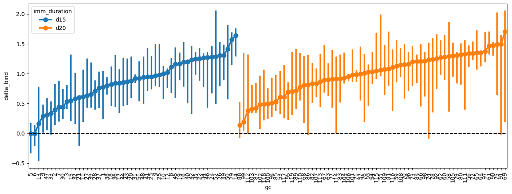

```python
plt.figure(figsize=(13, 5))
sns.pointplot(
    data=cell_table,
    hue="imm_duration",
    x="gc", order=cell_table.groupby("gc").agg(dict(imm_duration="first", delta_expr="median")).sort_values(["imm_duration", "delta_expr"]).index,
    y="delta_expr",
    estimator="median",
    errorbar=("pi", 50),
    )
plt.axhline(0, color="black", linestyle="--")
plt.xticks(rotation=90)
plt.tight_layout()
plt.savefig(f"{output_dir}/delta_expr.pdf")
plt.show()
```

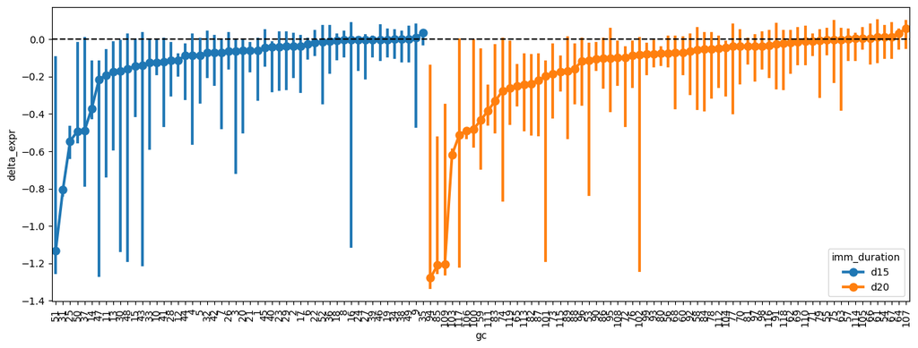

```python
g = sns.JointGrid(data=cell_table, x="delta_bind", y="delta_expr", hue="imm_duration")
g.plot_joint(sns.scatterplot)
g.plot_marginals(sns.kdeplot, common_norm=False, fill=True, alpha=0.1)
g.ax_joint.axvline(0, color="black", linestyle="--")
g.ax_joint.axhline(0, color="black", linestyle="--")
g.ax_marg_x.axvline(0, color="black", linestyle="--")
g.ax_marg_y.axhline(0, color="black", linestyle="--")
plt.tight_layout()
plt.savefig(f"{output_dir}/joint_cells.pdf")
plt.show()
```

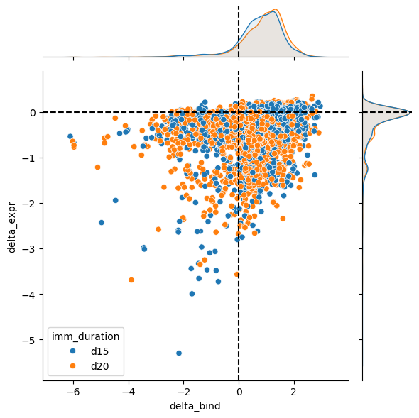

## GC-wise stats

```python
gc_summary = (
    (
        cell_table.groupby("gc").agg(
            uid = pd.NamedAgg(column="uid", aggfunc="first"),
            mouse = pd.NamedAgg(column="mouse", aggfunc="first"),
            ngs_id = pd.NamedAgg(column="ngs_id", aggfunc="first"),
            sampling_time=pd.NamedAgg(column="imm_duration", aggfunc="first"),
            cells_sampled=pd.NamedAgg(column="uid", aggfunc="count"),
            median_delta_bind=pd.NamedAgg(column="delta_bind", aggfunc="median"),
            median_delta_expr=pd.NamedAgg(column="delta_expr", aggfunc="median")
        )
    )
    .reset_index()
    .set_index("uid")
    .rename(
        columns={
            'median_delta_bind': 'median Δaffinity',
            'median_delta_expr': 'median Δexpression'
        }
    )
)

gc_summary
```

| uid | gc | mouse | ngs_id | sampling_time | cells_sampled | median Δaffinity | median Δexpression |
| --- | --- | --- | --- | --- | --- | --- | --- |
| D15_M1_GC1 | 1 | 1 | PR-2-01 | d15 | 67 | 0.773400 | -0.05788 |
| D15_M1_GC2 | 2 | 1 | PR-2-01 | d15 | 79 | 0.397360 | -0.03688 |
| D15_M1_GC3 | 3 | 1 | PR-2-01 | d15 | 73 | 0.535100 | -0.06153 |
| D15_M2_GC4 | 4 | 2 | PR-2-01 | d15 | 44 | 0.287630 | -0.08646 |
| D15_M3_GC5 | 5 | 3 | PR-2-01 | d15 | 78 | 0.000000 | -0.08452 |
| ... | ... | ... | ... | ... | ... | ... | ... |
| D20_M24_GC115 | 115 | 24 | PR-1-04 | d20 | 85 | 1.046480 | -0.17240 |
| D20_M25_GC116 | 116 | 25 | PR-1-02 | d20 | 78 | 1.105020 | -0.03121 |
| D20_M25_GC117 | 117 | 25 | PR-1-03 | d20 | 76 | 0.608315 | -0.51338 |
| D20_M25_GC118 | 118 | 25 | PR-1-08 | d20 | 70 | 0.492355 | -0.02191 |
| D20_M25_GC119 | 119 | 25 | PR-1-08 | d20 | 81 | 0.700545 | -0.26017 |

119 rows × 7 columns

```python
cols_to_keep = [
    # 'cells sampled',
    'normalized dominance score',
    'maximum REI',
    'max Δaffinity',
    '95th percentile Δaffinity',
    # 'mean Δaffinity',
    # 'median Δaffinity',
    'id of max REI node',
    'mutations in max REI node',
    'Δaffinity of max REI node',
    'ΔΔaffinity of max REI node',
    'max REI node is root'
]
nds_lb = pd.read_csv(nds_lb_summary_csv, index_col="uid")[cols_to_keep]
nds_lb.info()
```

```
<class 'pandas.core.frame.DataFrame'>
Index: 119 entries, D20_M22_GC96 to D15_M13_GC31
Data columns (total 9 columns):
 #   Column                      Non-Null Count  Dtype
---  ------                      --------------  -----
 0   normalized dominance score  119 non-null    float64
 1   maximum REI                 119 non-null    float64
 2   max Δaffinity               119 non-null    float64
 3   95th percentile Δaffinity   119 non-null    float64
 4   id of max REI node          119 non-null    object
 5   mutations in max REI node   113 non-null    object
 6   Δaffinity of max REI node   119 non-null    float64
 7   ΔΔaffinity of max REI node  119 non-null    float64
 8   max REI node is root        119 non-null    bool
dtypes: bool(1), float64(6), object(2)
memory usage: 8.5+ KB
```

```python
gc_summary = gc_summary.join(nds_lb)
gc_summary.to_csv(f"{output_dir}/gc_summary.csv")
```

```python
gc_summary.info()
```

```
<class 'pandas.core.frame.DataFrame'>
Index: 119 entries, D15_M1_GC1 to D20_M25_GC119
Data columns (total 16 columns):
 #   Column                      Non-Null Count  Dtype
---  ------                      --------------  -----
 0   gc                          119 non-null    int64
 1   mouse                       119 non-null    int64
 2   ngs_id                      119 non-null    object
 3   sampling_time               119 non-null    object
 4   cells_sampled               119 non-null    int64
 5   median Δaffinity            119 non-null    float64
 6   median Δexpression          119 non-null    float64
 7   normalized dominance score  119 non-null    float64
 8   maximum REI                 119 non-null    float64
 9   max Δaffinity               119 non-null    float64
 10  95th percentile Δaffinity   119 non-null    float64
 11  id of max REI node          119 non-null    object
 12  mutations in max REI node   113 non-null    object
 13  Δaffinity of max REI node   119 non-null    float64
 14  ΔΔaffinity of max REI node  119 non-null    float64
 15  max REI node is root        119 non-null    bool
dtypes: bool(1), float64(8), int64(3), object(4)
memory usage: 19.1+ KB
```

```python
g = sns.JointGrid(data=gc_summary, x="median Δaffinity", y="median Δexpression", hue="sampling_time")
g.plot_joint(sns.scatterplot, size=gc_summary.cells_sampled)
g.plot_marginals(sns.kdeplot, common_norm=False)
g.ax_joint.axvline(0, color="black", linestyle="--")
g.ax_joint.axhline(0, color="black", linestyle="--")
g.ax_marg_x.axvline(0, color="black", linestyle="--")
g.ax_marg_y.axhline(0, color="black", linestyle="--")
plt.tight_layout()
plt.savefig(f"{output_dir}/joint_gc_medians.pdf")
plt.show()
```

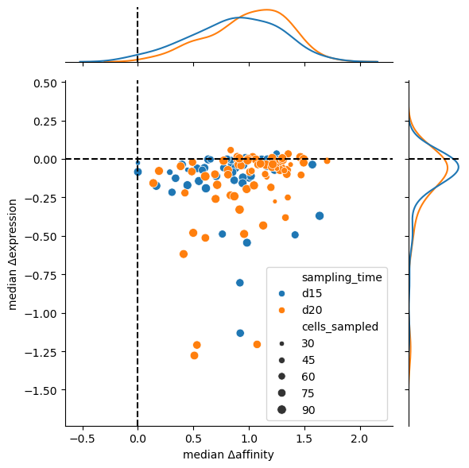

```python
sns.boxenplot(data=gc_summary, y="median Δaffinity", hue="sampling_time")
plt.show()
sns.boxenplot(data=gc_summary, y="median Δexpression", hue="sampling_time")
plt.show()
```

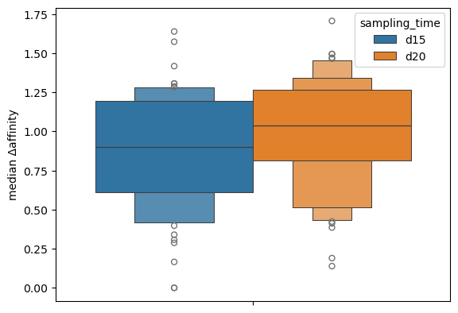

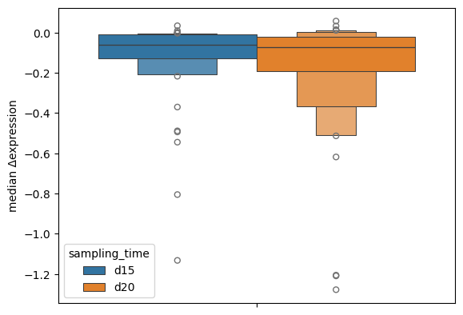